# Priority Vacant Posts — Web dashboard user guide

Paste screenshots under `docs/images/` (exact filenames), then render — output is one self-contained HTML file

Author

OPSC / PSC ICT

Published

May 6, 2026

**TipProduce `user-guide.html`**

1. Install [Quarto](https://quarto.org/docs/get-started/) **and [R](https://cran.r-project.org/)**.
2. Copy PNG or JPEG screenshots into **`docs/images/`**, using filenames from the cheat-sheet at the bottom (or rename your files).
3. In a terminal, run **`quarto render docs/user-guide.qmd`** from the **repository root** — or **`cd docs`** then **`quarto render user-guide.qmd`**.
4. Open **`docs/user-guide.html`** in a browser. **`embed-resources: true`** in this file packs theme, **`styles.css`**, scripts, and all images into **that single HTML file** — you do not need a separate `_files` folder or **`images/`** next to it when emailing or uploading the guide.

**Optional:** Copy **`user-guide.html`** only into **`psc-pvp-dashboard/public/docs/`** (rebuild/render first so screenshots are baked in) to refresh the sidebar **Update guide** in the packaged site.

## What this covers

Updating the internet dashboard using **Excel** (**`ministries_pvp.xlsx`**, **`data`** sheet) and **GitHub Desktop**. No Git commands or coding required.

**Example site:** mag-services.github.io/psc-pvp-dashboard/

## Plain vocabulary

| Term | Meaning |
| --- | --- |
| GitHub | ICT’s online folder for official files. |
| Repository | One project folder on GitHub. |
| Clone | One-time download onto your laptop. |
| Commit | Saves a labelled change in Desktop. |
| Push | Sends that save to GitHub so the web build runs. |

## Live dashboard screenshot

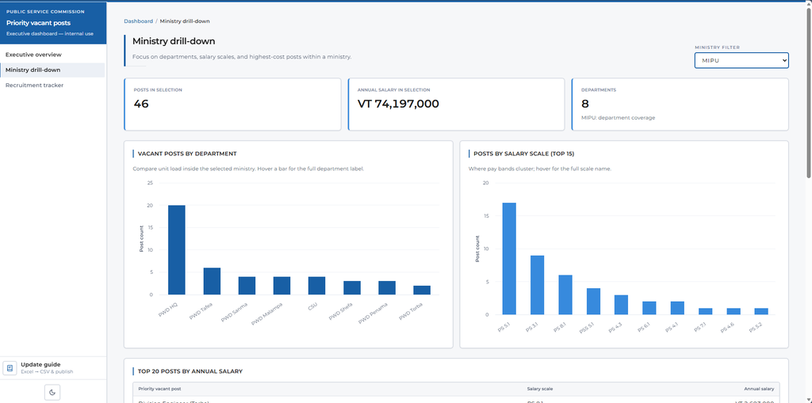

## Software (install once)

You only need ordinary office and Git tooling; no command line required for the steps in this guide.

- **Excel**
- **GitHub Desktop** — [desktop.github.com](https://desktop.github.com/)
- **GitHub** account — your team may invite you to the repo

Download GitHub Desktop from the official page, install it, then sign in with the GitHub account your organisation uses so you can clone and push updates.

# First-time only

**Note**

Skip if the dashboard repository already appears in the left sidebar of GitHub Desktop.

## Step A — File → Clone repository

In GitHub Desktop, open the **File** menu and choose **Clone repository**. This starts the one‑time download of the dashboard project folder to your laptop.

## Step B — URL & local folder, then Clone

Paste the HTTPS URL your ICT team supplied (or pick the repo under the **GitHub.com** tab), choose a sensible local folder, then click **Clone**. Wait until the download finishes — you only do this once per machine unless you delete the clone.

## Step C — Repository open in Desktop

When cloning completes, GitHub Desktop should show the dashboard repository selected in the left sidebar and an empty **History** or **Changes** view. You’ll use this same screen for every data refresh.

# Every refresh of data

## Step 1 — Pick the dashboard repository

Open GitHub Desktop and click the dashboard repository name in the **left sidebar** so you’re not editing the wrong project.

## Step 2 — Current branch should be **main**

Check the branch control (usually **Current branch**) shows **`main`** (or the branch your ICT team designates). Editing on the wrong branch can block your update from appearing on the public site.

## Step 3 — Repository → Show in Explorer (Windows) or Show in Finder (Mac)

Use the **Repository** menu to reveal the cloned folder on disk. Always open Excel from **this** folder so GitHub Desktop can see your save. On a typical **Windows** PC the clone is often under **`Documents`** — for example **`Documents\spsc-pvp-dashboard`** — but the path matches whatever folder you picked when you first cloned.

## Step 4 — Open `public\data` · find **`ministries_pvp.xlsx`**

In the window that opens, open **`public`**, then **`data`**, and locate **`ministries_pvp.xlsx`**. On Windows you may first see something like **`Documents\spsc-pvp-dashboard\`** (or another root name such as **`psc-pvp-dashboard`**, depending on how you cloned) — open folders until you reach **`public\data`**.

## Step 5 — Open workbook in Excel

Double‑click **`ministries_pvp.xlsx`** so Excel loads the **same copy** Desktop just showed you. Opening a copy from email or Downloads will not update GitHub Desktop.

## Step 6 — Click **data** sheet tab

At the bottom of Excel, switch to the **`data`** worksheet. Other sheets may exist — the dashboard reads this tab only.

## Step 7 — Edit under header row • keep row 1 titles

Edit or add rows **below** row **1**. Do **not** rename, delete, merge, or reorder the header row — column names must stay exactly as supplied or the site may fail to load.

## Step 8 — Save (Ctrl + S) · close Excel

Press **Ctrl + S** (Windows) or **⌘ + S** (Mac) to save, wait for any “Saving…” to finish, then fully **close Excel**. An unsaved or still‑open file can prevent Desktop from picking up changes.

## Step 9 — GitHub Desktop **Changes**

Return to GitHub Desktop and select the **Changes** tab (or equivalent). **`ministries_pvp.xlsx`** should appear as a modified file with a green/red diff summary.

**Warning**

Nothing listed? Excel was probably saved elsewhere — redo Steps 3→5 opening from Explorer only.

## Step 10 — Summary & **Commit to main**

In the bottom **Summary** box, type a short message (for example `Update vacant posts data` or the date). Click **Commit to main** to record the change **locally** — you still need to push for the website to update.

## Step 11 — **Push origin**

Click **Push origin** (or **Push** if your layout differs) to upload the commit to GitHub. This triggers the automated build that publishes the dashboard — allow **about 2–5 minutes** after that succeeds before the live site reliably shows your edits (**longer** if you changed a **lot** of data); Steps **12–14** walk through confirming the deploy and refreshing your browser.

## Step 12 — github.com • **Actions** • green ✔

On **github.com**, open the repository **Actions** tab and wait for the latest workflow run to show a **green check** (success). A red X means the deploy failed — contact ICT with the log link before telling stakeholders the site is updated.

Even after green ✔ finishes, give the published site **about 2–5 minutes** before expecting your changes everywhere; **large updates** (many rows or a big workbook) tend toward the **longer** end of that range.

## Step 13 — Open live dashboard

Open the public dashboard URL in your browser. If the address is bookmarked, use that; otherwise use the link your team shared (for example the **Example site** link at the top of this guide).

If headlines or tables still reflect the old export, wait the **same 2–5 minute window** after Actions went green (see Step 12), then use Step 14 to hard‑refresh — caching can make an updated site **look** stale for one more reload cycle.

## Step 14 — Hard refresh (**Ctrl + F5** / Cmd ⇧ R)

Browsers cache files. Once you’ve allowed enough time after deploy (typically **2–5 minutes**, more for heavier updates — Step 12), force a reload: **Ctrl + F5** (Windows/Linux) or **Cmd + Shift + R** (Mac). Then recheck headlines and detail tables.

## Privacy

On public GitHub Pages the **`.xlsx`** can be downloaded by anyone — only publish data your organisation clears.

## Excel headers (never rename row 1)

| Column | Meaning |
| --- | --- |
| MINISTRY | Blank ⇒ row ignored |
| DEPARTMENT | Department |
| PRIORITY VACANT POSTS | Post title shown |
| POST NUMBER | ID |
| SALARY SCALE | Scale label |
| ANNUAL SALARY | Numeric |
| RECRUITMENT STATUS | Controlled list |

## Recruitment statuses

Unknown Status · Vacant · Advertisement · Recruitment Process · Awaits Commission Decision · Occupied (Acting) · Occupied (Contract) · Filled · Filled (Internship) · Filled (Temporary).

Empty cell ⇒ **Unknown Status**. Headline KPIs treat **Vacant** + **Unknown Status** together as backlog.

## OPTIONAL — ICT / developers

Dashboard loads **`./data/ministries_pvp.xlsx`** (browser). Source in repo **`public/data/ministries_pvp.xlsx`**.

```
psc-pvp-dashboard/public/data/ministries_pvp.xlsx
```

## Screenshot filename cheat‑sheet

Paste PNGs (`docs/images/`) matching:

`intro-01-live-dashboard-overview.png` `first-01-download-github-desktop.png` `first-02-sign-in-to-github.png` `first-03-file-clone-repository.png` `first-04-clone-dialog-url-path.png` `first-05-repository-open-in-desktop.png`

`update-01-select-repository-left-sidebar.png` `update-02-current-branch-main.png` `update-03-menu-repository-show-in-explorer.png` `update-04-file-explorer-public-data-folder.png` `update-05-excel-open-ministries-workbook.png`

`update-06-excel-click-data-sheet-tab.png` `update-07-excel-edit-data-rows.png` `update-08-excel-save-and-close.png` `update-09-github-desktop-changes-listed.png` `update-10-summary-and-commit-to-main.png`

`update-11-push-origin.png` `update-12-github-actions-green-check.png` `update-13-live-dashboard-in-browser.png` `update-14-hard-refresh-ctrl-f5.png`